# Bioconductor Classes Quick Overview

## The GRanges Class

```r
library(GenomicRanges)
library("Gviz")
library("DESeq2")
```

Create a GRanges object

```r
(A1 <- GRanges(seqnames = Rle("ch1"),
              ranges   = IRanges(start = c(10, 22, 40),
                                 width = 5),
              strand   = "+"))
```

```
## GRanges object with 3 ranges and 0 metadata columns:
##       seqnames    ranges strand
##          <Rle> <IRanges>  <Rle>
##   [1]      ch1  [10, 14]      +
##   [2]      ch1  [22, 26]      +
##   [3]      ch1  [40, 44]      +
##   -------
##   seqinfo: 1 sequence from an unspecified genome; no seqlengths
```

Plot the ranges

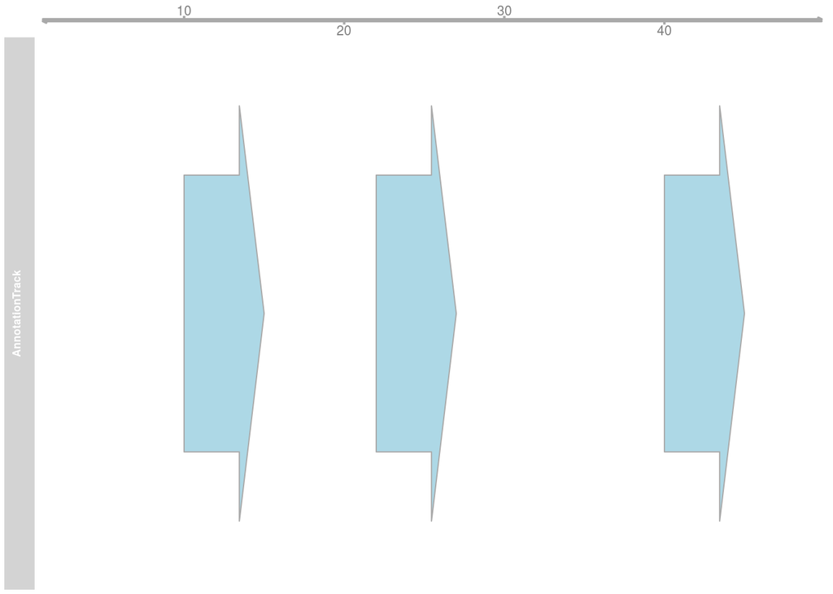

```r
options(ucscChromosomeNames=FALSE)
geTrack <- GenomeAxisTrack()
deTrack <- AnnotationTrack(range =  A1)
plotTracks(c(geTrack,deTrack),from=1, to=50)
```

Show all methods for the GRanges class

```r
methods(class="GRanges")
```

```
##   [1] aggregate         anyNA             <=
##   [4] <                 ==                >=
##   [7] >                 !=                append
##  [10] as.character      as.complex        as.data.frame
##  [13] as.env            as.factor         as.integer
##  [16] as.list           as.logical        as.matrix
##  [19] as.numeric        as.raw            by
##  [22] c                 coerce            coerce<-
##  [25] countOverlaps     coverage          disjoin
##  [28] disjointBins      distance          distanceToNearest
##  [31] duplicated        elementMetadata<- elementMetadata
##  [34] end<-             end               eval
##  [37] expand.grid       expand            extractROWS
##  [40] findOverlaps      flank             follow
##  [43] gaps              [                 $<-
```

[output cut: 31 more lines]

### Intra-range methods (transform ranges independently)

**shift(x)**: moves left/right

**promoters(x)**: returns promoter ranges extending around the transcription start site (TSS) defined as start(x)

### Inter-range methods (transform all the ranges together)

**reduce(x)**: orders the ranges in x from left to right, then merges the overlapping or adjacent ones

**disjoin(x)**: breaks into discrete ranges based on original starts/ends

For example:

```r
 length(A1)
```

```
## [1] 3
```

```r
 width(A1)
```

```
## [1] 5 5 5
```

```r
 seqnames(A1)
```

```
## factor-Rle of length 3 with 1 run
##   Lengths:   3
##   Values : ch1
## Levels(1): ch1
```

```r
 ranges(A1)
```

```
## IRanges object with 3 ranges and 0 metadata columns:
##           start       end     width
##       <integer> <integer> <integer>
##   [1]        10        14         5
##   [2]        22        26         5
##   [3]        40        44         5
```

```r
 promoters(A1,upstream=10, downstream=15)
```

```
## GRanges object with 3 ranges and 0 metadata columns:
##       seqnames    ranges strand
##          <Rle> <IRanges>  <Rle>
##   [1]      ch1  [ 0, 24]      +
##   [2]      ch1  [12, 36]      +
##   [3]      ch1  [30, 54]      +
##   -------
##   seqinfo: 1 sequence from an unspecified genome; no seqlengths
```

Add metdata to the GRanges object

```r
 names(A1) <- LETTERS[1:3]
 genome(A1) <- "hg19"
 mcols(A1)$bioreplicate <-  "I"
 A1
```

```
## GRanges object with 3 ranges and 1 metadata column:
##     seqnames    ranges strand | bioreplicate
##        <Rle> <IRanges>  <Rle> |  <character>
##   A      ch1  [10, 14]      + |            I
##   B      ch1  [22, 26]      + |            I
##   C      ch1  [40, 44]      + |            I
##   -------
##   seqinfo: 1 sequence from hg19 genome; no seqlengths
```

Coerce the GRange into a dataframe object

```r
as.data.frame(A1)
```

```
##   seqnames start end width strand bioreplicate
## A      ch1    10  14     5      +            I
## B      ch1    22  26     5      +            I
## C      ch1    40  44     5      +            I
```

### Multiple GRange Objects

Create two more objects

```r
A2 <- GRanges(seqnames = Rle("ch1"),
              ranges   = IRanges(start = c(8, 22, 29),
                                 width = 5),
              strand   = "+")

 names(A2) <- LETTERS[1:3]
 genome(A2) <- "hg19"
 mcols(A2)$bioreplicate <-  "II"

A3 <- GRanges(seqnames = Rle("ch1"),
              ranges   = IRanges(start = c(6, 15, 36),
                                 width = 5),
              strand   = "+")

 names(A3) <- LETTERS[1:3]
 genome(A3) <- "hg19"
 mcols(A3)$bioreplicate <-  "III"

 A2
```

```
## GRanges object with 3 ranges and 1 metadata column:
##     seqnames    ranges strand | bioreplicate
##        <Rle> <IRanges>  <Rle> |  <character>
##   A      ch1  [ 8, 12]      + |           II
##   B      ch1  [22, 26]      + |           II
##   C      ch1  [29, 33]      + |           II
##   -------
##   seqinfo: 1 sequence from hg19 genome; no seqlengths
```

```r
 A3
```

```
## GRanges object with 3 ranges and 1 metadata column:
##     seqnames    ranges strand | bioreplicate
##        <Rle> <IRanges>  <Rle> |  <character>
##   A      ch1  [ 6, 10]      + |          III
##   B      ch1  [15, 19]      + |          III
##   C      ch1  [36, 40]      + |          III
##   -------
##   seqinfo: 1 sequence from hg19 genome; no seqlengths
```

Combine the GRange objects

```r
(A <-  c(A1, A2, A3))
```

```
## GRanges object with 9 ranges and 1 metadata column:
##     seqnames    ranges strand | bioreplicate
##        <Rle> <IRanges>  <Rle> |  <character>
##   A      ch1  [10, 14]      + |            I
##   B      ch1  [22, 26]      + |            I
##   C      ch1  [40, 44]      + |            I
##   A      ch1  [ 8, 12]      + |           II
##   B      ch1  [22, 26]      + |           II
##   C      ch1  [29, 33]      + |           II
##   A      ch1  [ 6, 10]      + |          III
##   B      ch1  [15, 19]      + |          III
##   C      ch1  [36, 40]      + |          III
##   -------
##   seqinfo: 1 sequence from hg19 genome; no seqlengths
```

Merge

```r
(A_merged <- reduce(A))
```

```
## GRanges object with 4 ranges and 0 metadata columns:
##       seqnames    ranges strand
##          <Rle> <IRanges>  <Rle>
##   [1]      ch1  [ 6, 19]      +
##   [2]      ch1  [22, 26]      +
##   [3]      ch1  [29, 33]      +
##   [4]      ch1  [36, 44]      +
##   -------
##   seqinfo: 1 sequence from hg19 genome; no seqlengths
```

Plot it

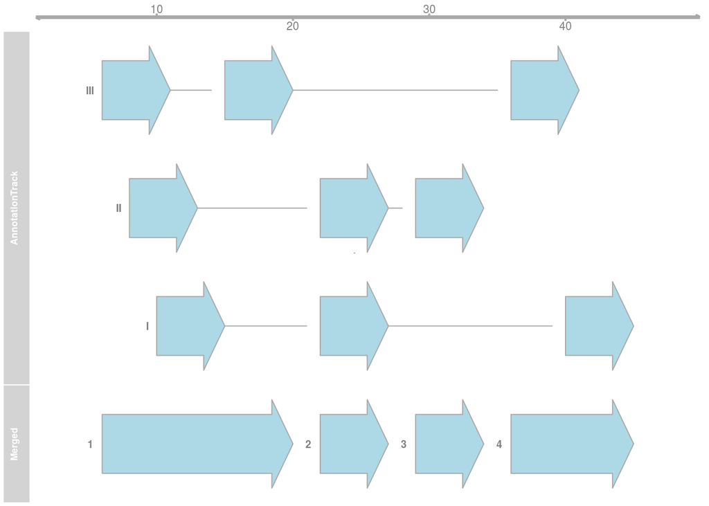

```r
deTrack <- AnnotationTrack(range =  A, group = A$bioreplicate)
mrgTrack <- AnnotationTrack(range =  A_merged, name = "Merged")
plotTracks(c(geTrack,deTrack, mrgTrack),groupAnnotation = "group",from=1, to=50)
```

To find ranges that repeat we can count the number of overlapping regions and remove merged segments that have a certain number of counts (e.g. 1)

```r
(cnts <- countOverlaps(A_merged,A))
```

```
## [1] 4 2 1 2
```

```r
A_merged_consensus <- A_merged[-which(cnts==1),]
```

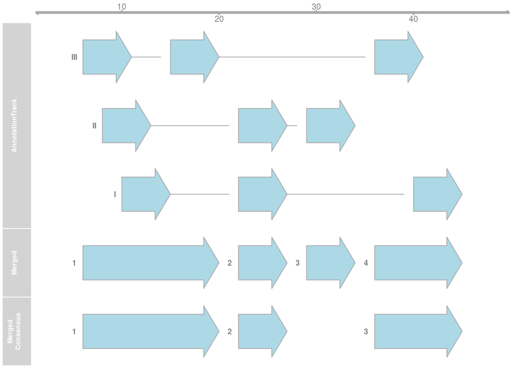

```r
mrg_con_Track <- AnnotationTrack(range =  A_merged_consensus,name = "Merged Consensus")
plotTracks(c(geTrack, deTrack, mrgTrack, mrg_con_Track),groupAnnotation = "group",from=1, to=50)
```

## GRangesList Class

The GRangesList class is a container for a list of GRanges objects that have the same metadata column variables. First we create another GRanges object.

```r
(B <- GRanges(seqnames = Rle("ch1"),
              ranges   = IRanges(start = c(1,3,10,13,24,30),
                                 width = 5),
              strand   = "+"))
```

```
## GRanges object with 6 ranges and 0 metadata columns:
##       seqnames    ranges strand
##          <Rle> <IRanges>  <Rle>
##   [1]      ch1  [ 1,  5]      +
##   [2]      ch1  [ 3,  7]      +
##   [3]      ch1  [10, 14]      +
##   [4]      ch1  [13, 17]      +
##   [5]      ch1  [24, 28]      +
##   [6]      ch1  [30, 34]      +
##   -------
##   seqinfo: 1 sequence from an unspecified genome; no seqlengths
```

```r
 names(B) <- rep(LETTERS[1:3],2)
 genome(B) <- "hg19"
 mcols(B)$bioreplicate <-  rep(c("I","II"),c(3,3))
# combine
AB <- GRangesList(A, B)
names(AB) <- c("A", "B")
(AB)
```

```
## GRangesList object of length 2:
## $A
## GRanges object with 9 ranges and 1 metadata column:
##     seqnames    ranges strand | bioreplicate
##        <Rle> <IRanges>  <Rle> |  <character>
##   A      ch1  [10, 14]      + |            I
##   B      ch1  [22, 26]      + |            I
##   C      ch1  [40, 44]      + |            I
##   A      ch1  [ 8, 12]      + |           II
##   B      ch1  [22, 26]      + |           II
##   C      ch1  [29, 33]      + |           II
##   A      ch1  [ 6, 10]      + |          III
##   B      ch1  [15, 19]      + |          III
##   C      ch1  [36, 40]      + |          III
##
## $B
## GRanges object with 6 ranges and 1 metadata column:
##     seqnames   ranges strand | bioreplicate
##   A      ch1 [ 1,  5]      + |            I
##   B      ch1 [ 3,  7]      + |            I
##   C      ch1 [10, 14]      + |            I
##   A      ch1 [13, 17]      + |           II
##   B      ch1 [24, 28]      + |           II
##   C      ch1 [30, 34]      + |           II
##
## -------
## seqinfo: 1 sequence from hg19 genome; no seqlengths
```

we can reduce each object independently

```r
(AB_merged <- reduce(AB))
```

```
## GRangesList object of length 2:
## $A
## GRanges object with 4 ranges and 0 metadata columns:
##       seqnames    ranges strand
##          <Rle> <IRanges>  <Rle>
##   [1]      ch1  [ 6, 19]      +
##   [2]      ch1  [22, 26]      +
##   [3]      ch1  [29, 33]      +
##   [4]      ch1  [36, 44]      +
##
## $B
## GRanges object with 4 ranges and 0 metadata columns:
##       seqnames   ranges strand
##   [1]      ch1 [ 1,  7]      +
##   [2]      ch1 [10, 17]      +
##   [3]      ch1 [24, 28]      +
##   [4]      ch1 [30, 34]      +
##
## -------
## seqinfo: 1 sequence from hg19 genome; no seqlengths
```

The GRangesList class is a List object (not list) of GenomicRanges

```r
(ABg <- GenomicRangesList(A, B))
```

```
## GenomicRangesList of length 2
```

We can also reduce the GRanges objects of all conditions into one GRange

```r
(AB_combined <- unlist(GenomicRangesList(A, B)))
```

```
## GRanges object with 15 ranges and 1 metadata column:
##     seqnames    ranges strand | bioreplicate
##        <Rle> <IRanges>  <Rle> |  <character>
##   A      ch1  [10, 14]      + |            I
##   B      ch1  [22, 26]      + |            I
##   C      ch1  [40, 44]      + |            I
##   A      ch1  [ 8, 12]      + |           II
##   B      ch1  [22, 26]      + |           II
##   .      ...       ...    ... .          ...
##   B      ch1  [ 3,  7]      + |            I
##   C      ch1  [10, 14]      + |            I
##   A      ch1  [13, 17]      + |           II
##   B      ch1  [24, 28]      + |           II
##   C      ch1  [30, 34]      + |           II
##   -------
##   seqinfo: 1 sequence from hg19 genome; no seqlengths
```

```r
(AB_combined_merged <- reduce(AB_combined ))
```

```
## GRanges object with 3 ranges and 0 metadata columns:
##       seqnames    ranges strand
##          <Rle> <IRanges>  <Rle>
##   [1]      ch1  [ 1, 19]      +
##   [2]      ch1  [22, 34]      +
##   [3]      ch1  [36, 44]      +
##   -------
##   seqinfo: 1 sequence from hg19 genome; no seqlengths
```

## RangedSummarizedExperiment

RangedSummarizedExperiment is a array-like container in which rows represent features of interest (e.g. genes) and columns represent samples.

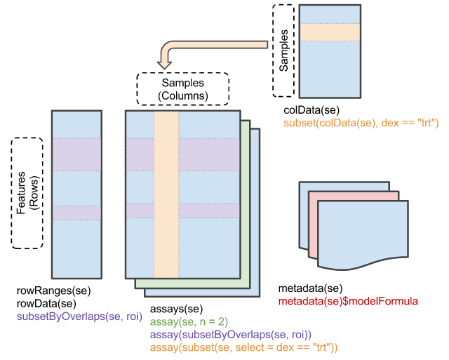

First we list the accessor functions for the class

```r
methods(class="RangedSummarizedExperiment")
```

```
##   [1] aggregate         anyNA             <=
##   [4] <                 ==                >=
##   [7] >                 !=                append
##  [10] as.character      as.complex        as.data.frame
##  [13] as.env            as.integer        as.list
##  [16] as.logical        as.matrix         as.numeric
##  [19] as.raw            assayNames<-      assayNames
##  [22] assays<-          assays            assay<-
##  [25] assay             by                cbind
##  [28] coerce<-          coerce            colData<-
##  [31] colData           Compare           countOverlaps
##  [34] coverage          dimnames<-        dimnames
##  [37] dim               disjointBins      distance
##  [40] distanceToNearest duplicated        elementMetadata<-
##  [43] elementMetadata   end<-             end
```

[output cut: 31 more lines]

We can construct a RangedSummarizedExperiment using the class constructor *SummarizedExperiment(assays, rowRanges, colData)* or it can be generated by other functions such as the *summarizeOverlaps* function that extends *findOverlaps* by providing options to resolve reads that overlap multiple features. For example given a list of bam files, we can geenerate a RangedSummarizedExperiment as such

```r
  se <- summarizeOverlaps(
    features = A_merged_consensus,
    reads = bam_files,
    mode = "Union",
    singleEnd = FALSE,
    ignore.strand = TRUE,
    fragments = TRUE,
    inter.feature = FALSE
  )

assays(se)[[1]]
colData(se)
colnames(se)
```

## DESeqDataSet Class

DESeqDataSet is a subclass of RangedSummarizedExperiment that serves as a container for differential expression analysis results. The *DESeqDataSet(se, design)* class constructor takes non-negative integer values in the counts *se* matrix and a formula to specifies the design of the experiment.

First we list the accessor functions for the class

```r
methods(class="DESeqDataSet")
```

```
##   [1] aggregate              anyNA                  <=
##   [4] <                      ==                     >=
##   [7] >                      !=                     append
##  [10] as.character           as.complex             as.data.frame
##  [13] as.env                 as.integer             as.list
##  [16] as.logical             as.matrix              as.numeric
##  [19] as.raw                 assayNames<-           assayNames
##  [22] assays<-               assays                 assay<-
##  [25] assay                  by                     cbind
##  [28] coef                   coerce<-               coerce
##  [31] colData<-              colData                Compare
##  [34] countOverlaps          counts<-               counts
##  [37] coverage               design<-               design
##  [40] dimnames<-             dimnames               dim
##  [43] disjointBins           dispersionFunction<-   dispersionFunction
```

[output cut: 36 more lines]

Examples of accessor functions for the class

```r
  DESeq_dataset <- DESeqDataSet(se, design = ~ biosample)
  DESeq_dataset <-DESeq_dataset[rowSums(counts(DESeq_dataset)) > 1, ]
  rld <- rlog(DESeq_dataset, blind=FALSE)
  #fragments per kilobase per million mapped fragments
  data_rpkm <-fpkm(rld)
  sampleDists <- dist( t( assay(rld) ) )
  ddsc  <- DESeq(DESeq_dataset)
  res <- results(dds)
  plotMA(res, ylim=c(-10,10))
```

To conduct differential analysis

```r
  ddsc  <- DESeq(DESeq_dataset)
 #DESeqResults object
  res <- results(dds)
  plotMA(res, ylim=c(-10,10))
  summary(res)
```